# Simple_rnaseq_analysis

Mario Ruiz Pérez

4/6/2022

## Loading data

The data was previously cleaned using unix pipline. The cleansing consisted on removing missing `NA` and zero `0,0` values.

```r
data = read.csv("genecounts.clean.tsv",sep="\t",header = TRUE, dec=",")

head(data)
```

```
##           ensgene control_1 treated_1 control_2 treated_2
## 1 ENSG00000000419       467       523       616       371
## 2 ENSG00000000457       347       258       364       237
## 3 ENSG00000000460        96        81        73        66
## 4 ENSG00000000971      3413      3916      6000      4308
## 5 ENSG00000001036      2328      1714      2640      1381
## 6 ENSG00000001084       670       372       692       448
```

As it can be seen, data consists of 5 columns. First one being an gene cDNA id and the other 4 the results of the read.

### Length

```r
rows = nrow(data)
```

## max cDNA count control_2

```r
max(data$control_2)
```

```
## [1] 510107
```

## Scatter plot

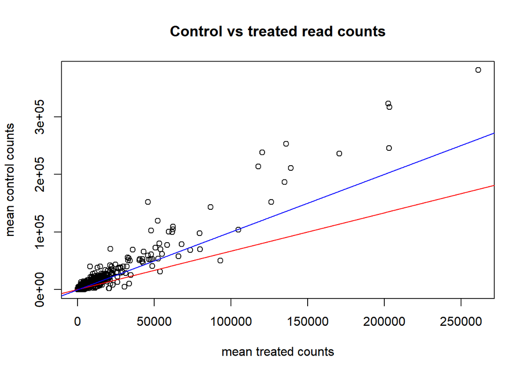

```r
data$treated_m = rowMeans(data[,c('treated_1','treated_2')])
data$control_m = rowMeans(data[,c('control_1','control_2')])

plot(data$treated_m,data$control_m,
     main="Control vs treated read counts",
     xlab="mean treated counts",
     ylab="mean control counts")

regresion <- lm(treated_m ~ control_m, data=data)
abline(regresion,col='red')
abline(a=0,b=1,col='blue')
```

We can see a little deviation from the expected line, this could mean two different things:

1.The treatment reduces the total rna produced 2.There is some sort of systematic bias.

The second option is more likely, in either case this should be taken into account when finding differential expressed genes.

Now we use the logarithm of the division to find differential expressed genes. It is used this method instead simple division for making the results more readable, compacting the plot.

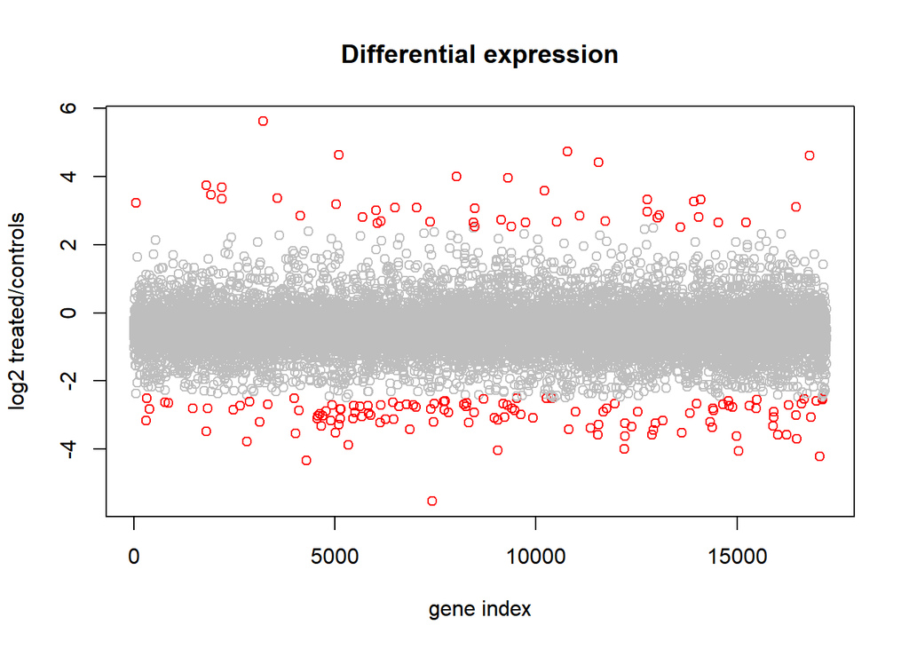

```r
data$log = log2(data$treated_m/data$control_m)
data$color[data$log > 2.5 | data$log < -2.5] = 'red'
data$color[data$log < 2.5 & data$log > -2.5] = 'grey'

plot(data$log,
     col=data$color,
     main="Differential expression",
     xlab="gene index",
     ylab="log2 treated/controls")
```